# VALT Summer School — Mapping & SQANTI-reads of long-read RNA-seq

**Session:** July 25, evening — *Mapping practical + SQANTI-reads*

**Data:** human **chromosome 8**, **H1 PacBio Iso-Seq** (full-length cDNA reads) — the same reads used in tomorrow's IsoTools and SQANTI3 sessions. **6 samples in 2 groups:** **`h1`** (undifferentiated H1 embryonic stem cells) vs **`endo`** (H1-derived endoderm), 3 replicates each.

### What you will do

1. **Map** long (Iso-Seq) reads to the genome with `minimap2` and inspect the alignments.
2. **Classify** every read against the reference annotation with **SQANTI3 QC** (structural categories).
3. **Aggregate** the 6 samples with **SQANTI-reads** — faceted by group (`endo` vs `h1`) — into QC tables + a multi-sample report, and **interpret** library quality and annotation completeness.

> **Cells marked `# TODO`** are for you to complete (hints in the comments). Run top-to-bottom. Use the **Python (SQANTI3)** kernel (top-right).

### Background: why "SQANTI-reads"?

Classic SQANTI3 characterizes a *transcriptome assembly*. **SQANTI-reads** runs the SQANTI3 structural classification on the **reads themselves**, fingerprints each read's splice pattern as a hashed **UJC** (Unique Junction Chain), and compares many samples/groups — to assess data quality and spot genes whose annotation looks incomplete. (Keil, Monzó, McIntyre & Conesa, *Genome Res* 2025.)

## 0. Setup

We work in your own writable directory. `data/` holds the per-sample reads and the chr8 reference. SQANTI3 writes intermediate files next to the input reads, so we first **copy** the FASTQs here.

```python
import os, sys, glob, shutil, subprocess, textwrap
import pandas as pd

# The 'Python (SQANTI3)' kernel runs the env's python but does NOT put the env's
# bin/ on PATH, so shell-escape (!) commands can't find minimap2/samtools/sqanti3_*.
# Prepend it here so `!minimap2 ...` etc. work in this notebook.
os.environ["PATH"] = os.path.dirname(sys.executable) + os.pathsep + os.environ.get("PATH", "")

# Threads per step — keep modest: the whole class shares this machine.
THREADS = 4

DATA    = "data"
REF_FA  = f"{DATA}/reference/GRCh38.p14.chr8.fa"
REF_GTF = f"{DATA}/reference/gencode.v45.chr8.gtf"

# 6 samples, 2 groups (the design for SQANTI-reads)
GROUP = {"endo_1":"endo","endo_2":"endo","endo_3":"endo","h1_1":"h1","h1_2":"h1","h1_3":"h1"}
SAMPLES = list(GROUP)

for s in SAMPLES:
    if not os.path.exists(f"{s}.fastq"):
        shutil.copy(f"{DATA}/{s}.fastq", f"{s}.fastq")

print("Reference :", REF_FA)
for s in SAMPLES:
    n = sum(1 for _ in open(f"{s}.fastq")) // 4
    print(f"  {s:7s} [{GROUP[s]:4s}] : {n:,} reads")
```

```
Reference : data/reference/GRCh38.p14.chr8.fa
  endo_1  [endo] : 25,000 reads
```

```
  endo_2  [endo] : 25,000 reads
  endo_3  [endo] : 25,000 reads
```

```
  h1_1    [h1  ] : 21,662 reads
  h1_2    [h1  ] : 25,000 reads
  h1_3    [h1  ] : 8,320 reads
```

```python
# Confirm the tools are on PATH (sqanti3 env)
!which minimap2 samtools sqanti3_qc.py sqanti3_reads.py
!minimap2 --version
```

```
~/.conda/envs/sqanti3/bin/minimap2
~/.conda/envs/sqanti3/bin/samtools
~/.conda/envs/sqanti3/bin/sqanti3_qc.py
~/.conda/envs/sqanti3/bin/sqanti3_reads.py
```

```
2.31-r1302
```

## Part 1 — Mapping practical

PacBio Iso-Seq reads are **full-length cDNA** spanning multiple exons, so the aligner must be **splice-aware** (it places long gaps = introns). `minimap2` has a preset for high-quality spliced cDNA: `-ax splice:hq`; `-uf` tells it transcripts come from the **forward** mRNA strand.

> **Note on the data:** these reads were pre-selected to chr8, so you'll see ~100% mapping here. With raw genome-wide reads, mapping rate is one of the first QC numbers you'd inspect.

```python
# Map one sample (endo_1) to chr8 with minimap2, then sort + index.
!minimap2 -t {THREADS} -ax splice:hq -uf {REF_FA} endo_1.fastq | samtools sort -@ {THREADS} -o endo_1.chr8.bam -
!samtools index endo_1.chr8.bam
print("done")
```

```
[M::mm_idx_gen::6.300*1.00] collected minimizers
```

```
[M::mm_idx_gen::7.347*1.42] sorted minimizers
[M::main::7.347*1.42] loaded/built the index for 1 target sequence(s)
```

```
[M::mm_mapopt_update::7.850*1.39] mid_occ = 179
[M::mm_idx_stat] kmer size: 15; skip: 5; is_hpc: 0; #seq: 1
```

```
[M::mm_idx_stat::8.251*1.37] distinct minimizers: 30821424 (77.73% are singletons); average occurrences: 1.607; average spacing: 2.930; total length: 145138636
```

```
[M::worker_pipeline::58.228*3.59] mapped 25000 sequences
```

```
[M::main] Version: 2.31-r1302
[M::main] CMD: minimap2 -t 4 -ax splice:hq -uf data/reference/GRCh38.p14.chr8.fa endo_1.fastq
[M::main] Real time: 58.286 sec; CPU: 208.966 sec; Peak RSS: 3.593 GB
```

```
[bam_sort_core] merging from 0 files and 4 in-memory blocks...
```

```
done
```

```python
# Alignment summary
!samtools flagstat endo_1.chr8.bam
```

```
25398 + 0 in total (QC-passed reads + QC-failed reads)
25000 + 0 primary
312 + 0 secondary
86 + 0 supplementary
0 + 0 duplicates
0 + 0 primary duplicates
25397 + 0 mapped (100.00% : N/A)
24999 + 0 primary mapped (100.00% : N/A)
0 + 0 paired in sequencing
0 + 0 read1
0 + 0 read2
0 + 0 properly paired (N/A : N/A)
0 + 0 with itself and mate mapped
0 + 0 singletons (N/A : N/A)
0 + 0 with mate mapped to a different chr
0 + 0 with mate mapped to a different chr (mapQ>=5)
```

### Look at a spliced alignment

In the CIGAR string, **`N`** = a skipped reference region, i.e. an **intron**. Long `N` operations are the splice junctions the long read crosses.

```python
import pysam
bam = pysam.AlignmentFile("endo_1.chr8.bam", "rb")
for r in bam.fetch():
    if not r.is_secondary and not r.is_supplementary and r.cigarstring and "N" in r.cigarstring:
        n_introns = sum(1 for op, _ in r.cigartuples if op == 3)  # 3 = N
        print(f"read {r.query_name}")
        print(f"  pos chr8:{r.reference_start:,}  introns(N)={n_introns}")
        print(f"  CIGAR (first 90 chars): {r.cigarstring[:90]}")
        break
bam.close()
```

```
read m54284U_201219_145906/162269437/ccs
  pos chr8:232,377  introns(N)=5
  CIGAR (first 90 chars): 38M8408N84M1979N127M708N84M813N83M452N160M1I7M1I21M3D96M1D188M1D129M1I317M1D435M1I117M1D16
```

**Q1.** What fraction of reads are *primary* vs *secondary/supplementary*? What does a secondary alignment mean for a full-length transcript read? **Q2.** Roughly how many introns does the example read cross? How would mono-exon reads look?

## Part 2 — SQANTI3 QC + SQANTI-reads aggregation

`sqanti3_reads.py`:

1. runs **SQANTI3 QC** on each sample (maps reads with minimap2 and classifies every read into a **structural category** — FSM, ISM, NIC, NNC, … — relative to the reference annotation),
2. computes a **UJC** (hashed splice-chain) per read,
3. **aggregates** all samples into QC tables and a report.

It is driven by a **design file**. Ours has a **`group`** column (`endo` vs `h1`); passing `--factor group` makes SQANTI-reads facet the plots by group so we can compare the two cell states.

```python
# Design file: sampleID, file_acc (= FASTQ name prefix), and the group factor.
rows = "sampleID,file_acc,group\n" + "\n".join(f"{s},{s},{GROUP[s]}" for s in SAMPLES) + "\n"
open("design.csv", "w").write(rows)
print(rows)
```

```
sampleID,file_acc,group
endo_1,endo_1,endo
endo_2,endo_2,endo
endo_3,endo_3,endo
h1_1,h1_1,h1
h1_2,h1_2,h1
h1_3,h1_3,h1
```

```python
# Run SQANTI-reads end-to-end on all 6 samples, faceted by group (~20 minutes).
!sqanti3_reads.py \
    --refFasta {REF_FA} --refGTF {REF_GTF} \
    -de design.csv -i . -o out \
    -f group -t {THREADS} --report pdf --all_tables
print("SQANTI-reads finished")
```

[output not shown]

```
[INFO:2026-06-24 20:04:39,996] Write arguments to /repo/home/biouser2/valt_exec_h1/out/endo_1/endo_1.qc_params.txt
[INFO:2026-06-24 20:04:39,997] Initialising QC pipeline.
[INFO:2026-06-24 20:04:39,997] Parsing provided files
[INFO:2026-06-24 20:04:39,997] Reading genome fasta /repo/home/biouser2/valt_exec_h1/data/reference/GRCh38.p14.chr8.fa
```

```
[INFO:2026-06-24 20:04:40,940] **** Correcting sequences
[INFO:2026-06-24 20:04:40,940] Correcting fasta
[INFO:2026-06-24 20:04:40,940] Cleaning up isoform IDs...
```

```
[INFO:2026-06-24 20:04:42,886] Cleaned up isoform fasta file written to: /repo/home/biouser2/valt_exec_h1/endo_1.renamed.fasta
[INFO:2026-06-24 20:04:42,887] ****Aligning reads with Minimap2...
```

```
output written to /repo/home/biouser2/valt_exec_h1/out/endo_1/endo_1_corrected.fasta
```

```
[INFO:2026-06-24 20:05:51,444] **** Predicting ORF sequences...
[WARNING:2026-06-24 20:05:51,445] Skipping ORF prediction because user requested it. All isoforms will be non-coding!
[WARNING:2026-06-24 20:05:51,445] All input isoforms were predicted as non-coding
[INFO:2026-06-24 20:05:51,445] **** Parsing Reference Transcriptome....
```

```
[INFO:2026-06-24 20:05:52,815] **** Parsing Isoforms.
```

```
[INFO:2026-06-24 20:05:57,444] No short-reads or coverage provided. Skipping short-read coverage calculation.
[INFO:2026-06-24 20:05:57,444] TSS ratio will not be calculated since SR information was not provided
[INFO:2026-06-24 20:05:57,444] **** Performing Classification of Isoforms
```

```
[INFO:2026-06-24 20:07:53,659] Number of classified isoforms: 25091
```

```
[INFO:2026-06-24 20:07:53,740] After classify fsm: 25091
[INFO:2026-06-24 20:07:53,740] Full-length read abundance files not provided.
[INFO:2026-06-24 20:07:53,740] RT-switching computation
```

```
[INFO:2026-06-24 20:07:54,599] After RTS classification: 25091
[INFO:2026-06-24 20:07:54,600] Isoforms expression files not provided.
```

```
[INFO:2026-06-24 20:07:55,319] Writing output files
```

```
[INFO:2026-06-24 20:07:57,432] **** Generating SQANTI3 report.
```

```
[INFO:2026-06-24 20:08:28,339] Removing temporary files.
[INFO:2026-06-24 20:08:28,339] SQANTI3 complete in 228.34 sec.
```

[output not shown]

```
[INFO:2026-06-24 20:08:29,490] Write arguments to /repo/home/biouser2/valt_exec_h1/out/endo_2/endo_2.qc_params.txt
[INFO:2026-06-24 20:08:29,491] Initialising QC pipeline.
[INFO:2026-06-24 20:08:29,491] Parsing provided files
[INFO:2026-06-24 20:08:29,491] Reading genome fasta /repo/home/biouser2/valt_exec_h1/data/reference/GRCh38.p14.chr8.fa
```

```
[INFO:2026-06-24 20:08:30,423] **** Correcting sequences
[INFO:2026-06-24 20:08:30,423] Correcting fasta
[INFO:2026-06-24 20:08:30,423] Cleaning up isoform IDs...
```

```
[INFO:2026-06-24 20:08:32,319] Cleaned up isoform fasta file written to: /repo/home/biouser2/valt_exec_h1/endo_2.renamed.fasta
[INFO:2026-06-24 20:08:32,319] ****Aligning reads with Minimap2...
```

```
output written to /repo/home/biouser2/valt_exec_h1/out/endo_2/endo_2_corrected.fasta
```

```
[INFO:2026-06-24 20:09:41,547] **** Predicting ORF sequences...
[WARNING:2026-06-24 20:09:41,558] Skipping ORF prediction because user requested it. All isoforms will be non-coding!
[WARNING:2026-06-24 20:09:41,558] All input isoforms were predicted as non-coding
[INFO:2026-06-24 20:09:41,558] **** Parsing Reference Transcriptome....
```

```
[INFO:2026-06-24 20:09:43,270] **** Parsing Isoforms.
```

```
[INFO:2026-06-24 20:09:47,108] No short-reads or coverage provided. Skipping short-read coverage calculation.
[INFO:2026-06-24 20:09:47,117] TSS ratio will not be calculated since SR information was not provided
[INFO:2026-06-24 20:09:47,117] **** Performing Classification of Isoforms
```

```
[INFO:2026-06-24 20:11:45,363] Number of classified isoforms: 25103
```

```
[INFO:2026-06-24 20:11:45,457] After classify fsm: 25103
[INFO:2026-06-24 20:11:45,457] Full-length read abundance files not provided.
[INFO:2026-06-24 20:11:45,457] RT-switching computation
```

```
[INFO:2026-06-24 20:11:46,428] After RTS classification: 25103
[INFO:2026-06-24 20:11:46,438] Isoforms expression files not provided.
```

```
[INFO:2026-06-24 20:11:47,220] Writing output files
```

```
[INFO:2026-06-24 20:11:49,558] **** Generating SQANTI3 report.
```

```
[INFO:2026-06-24 20:12:18,630] Removing temporary files.
```

```
[INFO:2026-06-24 20:12:18,641] SQANTI3 complete in 229.15 sec.
```

[output not shown]

```
[INFO:2026-06-24 20:12:20,133] Write arguments to /repo/home/biouser2/valt_exec_h1/out/endo_3/endo_3.qc_params.txt
[INFO:2026-06-24 20:12:20,134] Initialising QC pipeline.
[INFO:2026-06-24 20:12:20,134] Parsing provided files
[INFO:2026-06-24 20:12:20,134] Reading genome fasta /repo/home/biouser2/valt_exec_h1/data/reference/GRCh38.p14.chr8.fa
```

```
[INFO:2026-06-24 20:12:20,976] **** Correcting sequences
[INFO:2026-06-24 20:12:20,979] Correcting fasta
[INFO:2026-06-24 20:12:20,979] Cleaning up isoform IDs...
```

```
[INFO:2026-06-24 20:12:23,203] Cleaned up isoform fasta file written to: /repo/home/biouser2/valt_exec_h1/endo_3.renamed.fasta
[INFO:2026-06-24 20:12:23,204] ****Aligning reads with Minimap2...
```

```
output written to /repo/home/biouser2/valt_exec_h1/out/endo_3/endo_3_corrected.fasta
```

```
[INFO:2026-06-24 20:13:32,261] **** Predicting ORF sequences...
[WARNING:2026-06-24 20:13:32,283] Skipping ORF prediction because user requested it. All isoforms will be non-coding!
[WARNING:2026-06-24 20:13:32,284] All input isoforms were predicted as non-coding
[INFO:2026-06-24 20:13:32,284] **** Parsing Reference Transcriptome....
```

```
[INFO:2026-06-24 20:13:35,055] **** Parsing Isoforms.
```

```
[INFO:2026-06-24 20:13:39,160] No short-reads or coverage provided. Skipping short-read coverage calculation.
[INFO:2026-06-24 20:13:39,160] TSS ratio will not be calculated since SR information was not provided
[INFO:2026-06-24 20:13:39,160] **** Performing Classification of Isoforms
```

```
[INFO:2026-06-24 20:15:30,076] Number of classified isoforms: 25115
```

```
[INFO:2026-06-24 20:15:30,145] After classify fsm: 25115
[INFO:2026-06-24 20:15:30,145] Full-length read abundance files not provided.
[INFO:2026-06-24 20:15:30,145] RT-switching computation
```

```
[INFO:2026-06-24 20:15:31,098] After RTS classification: 25115
[INFO:2026-06-24 20:15:31,108] Isoforms expression files not provided.
```

```
[INFO:2026-06-24 20:15:31,834] Writing output files
```

```
[INFO:2026-06-24 20:15:34,099] **** Generating SQANTI3 report.
```

```
[INFO:2026-06-24 20:16:05,149] Removing temporary files.
[INFO:2026-06-24 20:16:05,160] SQANTI3 complete in 225.03 sec.
```

[output not shown]

```
[INFO:2026-06-24 20:16:06,988] Write arguments to /repo/home/biouser2/valt_exec_h1/out/h1_1/h1_1.qc_params.txt
```

```
[INFO:2026-06-24 20:16:07,024] Initialising QC pipeline.
[INFO:2026-06-24 20:16:07,024] Parsing provided files
[INFO:2026-06-24 20:16:07,024] Reading genome fasta /repo/home/biouser2/valt_exec_h1/data/reference/GRCh38.p14.chr8.fa
```

```
[INFO:2026-06-24 20:16:07,898] **** Correcting sequences
```

```
[INFO:2026-06-24 20:16:07,907] Correcting fasta
[INFO:2026-06-24 20:16:07,908] Cleaning up isoform IDs...
```

```
[INFO:2026-06-24 20:16:09,849] Cleaned up isoform fasta file written to: /repo/home/biouser2/valt_exec_h1/h1_1.renamed.fasta
[INFO:2026-06-24 20:16:09,862] ****Aligning reads with Minimap2...
```

```
output written to /repo/home/biouser2/valt_exec_h1/out/h1_1/h1_1_corrected.fasta
```

```
[INFO:2026-06-24 20:17:14,362] **** Predicting ORF sequences...
```

```
[WARNING:2026-06-24 20:17:14,375] Skipping ORF prediction because user requested it. All isoforms will be non-coding!
[WARNING:2026-06-24 20:17:14,387] All input isoforms were predicted as non-coding
[INFO:2026-06-24 20:17:14,387] **** Parsing Reference Transcriptome....
```

```
[INFO:2026-06-24 20:17:17,092] **** Parsing Isoforms.
```

```
[INFO:2026-06-24 20:17:21,120] No short-reads or coverage provided. Skipping short-read coverage calculation.
[INFO:2026-06-24 20:17:21,120] TSS ratio will not be calculated since SR information was not provided
[INFO:2026-06-24 20:17:21,120] **** Performing Classification of Isoforms
```

```
[INFO:2026-06-24 20:19:20,438] Number of classified isoforms: 21712
```

```
[INFO:2026-06-24 20:19:20,505] After classify fsm: 21712
[INFO:2026-06-24 20:19:20,507] Full-length read abundance files not provided.
[INFO:2026-06-24 20:19:20,507] RT-switching computation
```

```
[INFO:2026-06-24 20:19:21,698] After RTS classification: 21712
[INFO:2026-06-24 20:19:21,708] Isoforms expression files not provided.
```

```
[INFO:2026-06-24 20:19:22,454] Writing output files
```

```
[INFO:2026-06-24 20:19:24,731] **** Generating SQANTI3 report.
```

```
[INFO:2026-06-24 20:19:56,014] Removing temporary files.
[INFO:2026-06-24 20:19:56,024] SQANTI3 complete in 229.0 sec.
```

[output not shown]

```
[INFO:2026-06-24 20:19:57,633] Write arguments to /repo/home/biouser2/valt_exec_h1/out/h1_2/h1_2.qc_params.txt
```

```
[INFO:2026-06-24 20:19:57,664] Initialising QC pipeline.
[INFO:2026-06-24 20:19:57,664] Parsing provided files
[INFO:2026-06-24 20:19:57,665] Reading genome fasta /repo/home/biouser2/valt_exec_h1/data/reference/GRCh38.p14.chr8.fa
```

```
[INFO:2026-06-24 20:19:58,611] **** Correcting sequences
[INFO:2026-06-24 20:19:58,612] Correcting fasta
[INFO:2026-06-24 20:19:58,612] Cleaning up isoform IDs...
```

```
[INFO:2026-06-24 20:20:00,760] Cleaned up isoform fasta file written to: /repo/home/biouser2/valt_exec_h1/h1_2.renamed.fasta
[INFO:2026-06-24 20:20:00,760] ****Aligning reads with Minimap2...
```

```
output written to /repo/home/biouser2/valt_exec_h1/out/h1_2/h1_2_corrected.fasta
```

```
[INFO:2026-06-24 20:21:08,171] **** Predicting ORF sequences...
[WARNING:2026-06-24 20:21:08,182] Skipping ORF prediction because user requested it. All isoforms will be non-coding!
[WARNING:2026-06-24 20:21:08,182] All input isoforms were predicted as non-coding
[INFO:2026-06-24 20:21:08,182] **** Parsing Reference Transcriptome....
```

```
[INFO:2026-06-24 20:21:10,533] **** Parsing Isoforms.
```

```
[INFO:2026-06-24 20:21:14,643] No short-reads or coverage provided. Skipping short-read coverage calculation.
```

```
[INFO:2026-06-24 20:21:14,653] TSS ratio will not be calculated since SR information was not provided
[INFO:2026-06-24 20:21:14,653] **** Performing Classification of Isoforms
```

```
[INFO:2026-06-24 20:23:17,674] Number of classified isoforms: 25064
```

```
[INFO:2026-06-24 20:23:17,771] After classify fsm: 25064
[INFO:2026-06-24 20:23:17,771] Full-length read abundance files not provided.
[INFO:2026-06-24 20:23:17,771] RT-switching computation
```

```
[INFO:2026-06-24 20:23:19,036] After RTS classification: 25064
[INFO:2026-06-24 20:23:19,045] Isoforms expression files not provided.
```

```
[INFO:2026-06-24 20:23:19,833] Writing output files
```

```
[INFO:2026-06-24 20:23:22,183] **** Generating SQANTI3 report.
```

```
[INFO:2026-06-24 20:23:54,112] Removing temporary files.
[INFO:2026-06-24 20:23:54,112] SQANTI3 complete in 236.45 sec.
```

[output not shown]

```
[INFO:2026-06-24 20:23:55,925] Write arguments to /repo/home/biouser2/valt_exec_h1/out/h1_3/h1_3.qc_params.txt
[INFO:2026-06-24 20:23:55,926] Initialising QC pipeline.
[INFO:2026-06-24 20:23:55,926] Parsing provided files
[INFO:2026-06-24 20:23:55,926] Reading genome fasta /repo/home/biouser2/valt_exec_h1/data/reference/GRCh38.p14.chr8.fa
```

```
[INFO:2026-06-24 20:23:56,802] **** Correcting sequences
```

```
[INFO:2026-06-24 20:23:56,809] Correcting fasta
[INFO:2026-06-24 20:23:56,809] Cleaning up isoform IDs...
```

```
[INFO:2026-06-24 20:23:57,480] Cleaned up isoform fasta file written to: /repo/home/biouser2/valt_exec_h1/h1_3.renamed.fasta
[INFO:2026-06-24 20:23:57,480] ****Aligning reads with Minimap2...
```

```
output written to /repo/home/biouser2/valt_exec_h1/out/h1_3/h1_3_corrected.fasta
```

```
[INFO:2026-06-24 20:24:24,597] **** Predicting ORF sequences...
[WARNING:2026-06-24 20:24:24,610] Skipping ORF prediction because user requested it. All isoforms will be non-coding!
[WARNING:2026-06-24 20:24:24,610] All input isoforms were predicted as non-coding
[INFO:2026-06-24 20:24:24,610] **** Parsing Reference Transcriptome....
```

```
[INFO:2026-06-24 20:24:26,472] **** Parsing Isoforms.
```

```
[INFO:2026-06-24 20:24:27,907] No short-reads or coverage provided. Skipping short-read coverage calculation.
[INFO:2026-06-24 20:24:27,907] TSS ratio will not be calculated since SR information was not provided
[INFO:2026-06-24 20:24:27,907] **** Performing Classification of Isoforms
```

```
[INFO:2026-06-24 20:25:09,104] Number of classified isoforms: 8342
[INFO:2026-06-24 20:25:09,141] After classify fsm: 8342
```

```
[INFO:2026-06-24 20:25:09,152] Full-length read abundance files not provided.
[INFO:2026-06-24 20:25:09,152] RT-switching computation
```

```
[INFO:2026-06-24 20:25:09,514] After RTS classification: 8342
[INFO:2026-06-24 20:25:09,516] Isoforms expression files not provided.
```

```
[INFO:2026-06-24 20:25:09,776] Writing output files
```

```
[INFO:2026-06-24 20:25:10,521] **** Generating SQANTI3 report.
```

```
[INFO:2026-06-24 20:25:37,022] Removing temporary files.
[INFO:2026-06-24 20:25:37,034] SQANTI3 complete in 101.11 sec.
```

```
[INFO:2026-06-24 20:25:37,302] **** Calculating UJCs...
```

```
Converting GTF to ENSEMBL format
```

```
Analyzing chromosomes:
['8']
```

```
[INFO:2026-06-24 20:25:42,511] **** Calculating UJCs...
```

```
Converting GTF to ENSEMBL format
```

```
Analyzing chromosomes:
['8']
```

```
[INFO:2026-06-24 20:25:47,062] **** Calculating UJCs...
```

```
Converting GTF to ENSEMBL format
```

```
Analyzing chromosomes:
['8']
```

```
[INFO:2026-06-24 20:25:51,472] **** Calculating UJCs...
```

```
Converting GTF to ENSEMBL format
```

```
Analyzing chromosomes:
['8']
```

```
[INFO:2026-06-24 20:25:55,298] **** Calculating UJCs...
```

```
Converting GTF to ENSEMBL format
```

```
Analyzing chromosomes:
['8']
```

```
[INFO:2026-06-24 20:26:00,594] **** Calculating UJCs...
```

```
Converting GTF to ENSEMBL format
```

```
Analyzing chromosomes:
['8']
```

```
[INFO:2026-06-24 20:26:02,455] Running SQANTI-reads tables and plots generation...
```

```
[INFO:2026-06-24 20:26:03,777] Starting SQANTI-reads tables and plots generation...
```

```
[INFO:2026-06-24 20:26:06,698] Loading junction file: endo_1
```

```
[INFO:2026-06-24 20:26:07,286] Loading classification file: endo_1
```

```
[INFO:2026-06-24 20:26:09,491] endo_1 done processing
[INFO:2026-06-24 20:26:09,496] Loading junction file: endo_2
```

```
[INFO:2026-06-24 20:26:10,049] Loading classification file: endo_2
```

```
[INFO:2026-06-24 20:26:12,164] endo_2 done processing
[INFO:2026-06-24 20:26:12,168] Loading junction file: endo_3
```

```
[INFO:2026-06-24 20:26:12,713] Loading classification file: endo_3
```

```
[INFO:2026-06-24 20:26:14,963] endo_3 done processing
```

```
[INFO:2026-06-24 20:26:14,973] Loading junction file: h1_1
```

```
[INFO:2026-06-24 20:26:15,571] Loading classification file: h1_1
```

```
[INFO:2026-06-24 20:26:17,472] h1_1 done processing
[INFO:2026-06-24 20:26:17,480] Loading junction file: h1_2
```

```
[INFO:2026-06-24 20:26:18,119] Loading classification file: h1_2
```

```
[INFO:2026-06-24 20:26:20,076] h1_2 done processing
[INFO:2026-06-24 20:26:20,087] Loading junction file: h1_3
```

```
[INFO:2026-06-24 20:26:20,305] Loading classification file: h1_3
```

```
[INFO:2026-06-24 20:26:21,436] h1_3 done processing
```

```
[INFO:2026-06-24 20:26:34,712] SQANTI-reads tables and plots generation completed.
```

```
SQANTI-reads finished
```

```python
print("Per-sample SQANTI3 output (endo_1):")
!ls out/endo_1 | head
print("\nAggregated SQANTI-reads tables + report:")
!ls -1 out/*.csv out/*.pdf 2>/dev/null
```

```
Per-sample SQANTI3 output (endo_1):
```

```
endo_1_classification.txt
endo_1_corrected.fasta
endo_1_corrected.genePred
endo_1_corrected.gtf
endo_1_corrected_indels.txt
endo_1_corrected.sam
endo_1_junctions.txt
endo_1.qc_params.txt
endo_1_reads_classification.txt
endo_1_SQANTI3_report.html
```

```
Aggregated SQANTI-reads tables + report:
```

```
out/processed_design.csv
out/sqantiReads_annotation_plots.pdf
out/sqantiReads_cv_acc_counts.csv
out/sqantiReads_cv.csv
out/sqantiReads_cv_don_counts.csv
out/sqantiReads_err_counts.csv
out/sqantiReads_FSM_counts.csv
out/sqantiReads_gene_classfication.csv
out/sqantiReads_gene_counts.csv
out/sqantiReads_ISM_counts.csv
out/sqantiReads_jxn_counts.csv
out/sqantiReads_length_summary.csv
out/sqantiReads_length_summary_w_category_percs.csv
out/sqantiReads_NIC_NNC_counts.csv
out/sqantiReads_plots.pdf
out/sqantiReads_putative_underannotation.csv
out/sqantiReads_structural_category_percs.csv
out/sqantiReads_ujc_counts.csv
```

## Part 3 — Explore the QC tables

SQANTI-reads writes one row per sample (or per gene/UJC). We load them with pandas (using `glob`, so the code is robust to the output prefix).

```python
def load(pattern):
    hits = glob.glob(f"out/*{pattern}*.csv")
    assert hits, f"no table matching {pattern}"
    return pd.read_csv(hits[0])

gene   = load("gene_counts")
ujc    = load("ujc_counts")
length = load("length_summary")
cv     = load("cv")
print("gene_counts   :", gene.shape)
print("ujc_counts    :", ujc.shape)
print("length_summary:", length.shape)
print("cv            :", cv.shape)
length
```

```
gene_counts   : (9399, 15)
ujc_counts    : (32850, 12)
length_summary: (6, 15)
cv            : (6, 5)
```

|  | sampleID | group | total_reads | reads_gt_1kb | reads_gt_2kb | reads_gt_3kb | perc_reads_gt_1kb | perc_reads_gt_2kb | perc_reads_gt_3kb | average_length | median_length | min_length | max_length | q25_length | q75_length |
| --- | --- | --- | --- | --- | --- | --- | --- | --- | --- | --- | --- | --- | --- | --- | --- |
| 0 | endo_1 | endo | 25091 | 21772 | 14635 | 7402 | 86.772149 | 58.327687 | 29.500618 | 2496.115260 | 2297.0 | 81 | 14960 | 1537.5 | 3273.5 |
| 1 | endo_2 | endo | 25103 | 20647 | 13130 | 6644 | 82.249134 | 52.304505 | 26.466956 | 2351.298172 | 2045.0 | 80 | 14091 | 1266.0 | 3116.0 |
| 2 | endo_3 | endo | 25115 | 20552 | 13410 | 7108 | 81.831575 | 53.394386 | 28.301812 | 2409.083615 | 2075.0 | 80 | 13616 | 1253.5 | 3226.5 |
| 3 | h1_1 | h1 | 21712 | 19304 | 14361 | 7196 | 88.909359 | 66.143147 | 33.142962 | 2691.206338 | 2653.0 | 81 | 13733 | 1693.0 | 3537.0 |
| 4 | h1_2 | h1 | 25064 | 19429 | 13520 | 6513 | 77.517555 | 53.941909 | 25.985477 | 2339.686124 | 2169.5 | 80 | 16546 | 1185.0 | 3078.0 |
| 5 | h1_3 | h1 | 8342 | 6867 | 4353 | 1515 | 82.318389 | 52.181731 | 18.161112 | 2172.516663 | 2047.0 | 80 | 9789 | 1330.0 | 2858.0 |

### Structural categories per sample (coloured intuition: endo vs h1)

The mix of categories is a quick read on library quality. Compare the two groups.

| structural_category | endo_1 | endo_2 | endo_3 | h1_1 | h1_2 | h1_3 |
| --- | --- | --- | --- | --- | --- | --- |
| full-splice_match | 17061 | 16787 | 16337 | 15632 | 17364 | 6157 |
| incomplete-splice_match | 2747 | 3080 | 3143 | 1987 | 3263 | 828 |
| novel_not_in_catalog | 1906 | 1734 | 1789 | 1697 | 1787 | 544 |
| novel_in_catalog | 1738 | 1533 | 1572 | 1390 | 1279 | 415 |
| genic_intron | 612 | 797 | 994 | 392 | 590 | 168 |
| antisense | 337 | 374 | 420 | 236 | 276 | 97 |
| intergenic | 328 | 444 | 468 | 86 | 148 | 45 |
| genic | 295 | 284 | 333 | 239 | 306 | 70 |
| fusion | 67 | 70 | 59 | 53 | 51 | 18 |

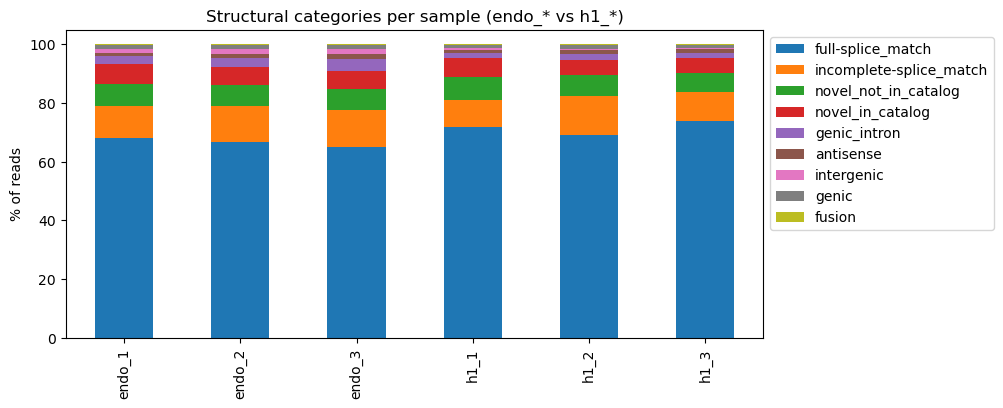

```python
frames = []
for s in SAMPLES:
    cls = pd.read_csv(f"out/{s}/{s}_classification.txt", sep="\t", usecols=["structural_category"])
    vc = cls["structural_category"].value_counts(); vc.name = s
    frames.append(vc)
cat = pd.concat(frames, axis=1).fillna(0).astype(int)[SAMPLES]
display(cat)
ax = (100*cat/cat.sum()).T.plot(kind="bar", stacked=True, figsize=(9,4))
ax.set_ylabel("% of reads"); ax.set_title("Structural categories per sample (endo_* vs h1_*)")
ax.legend(bbox_to_anchor=(1.0, 1.0));
```

### Read length per sample

`length_summary` summarises read lengths per sample (`median_length`, `% reads > 1kb`, …).

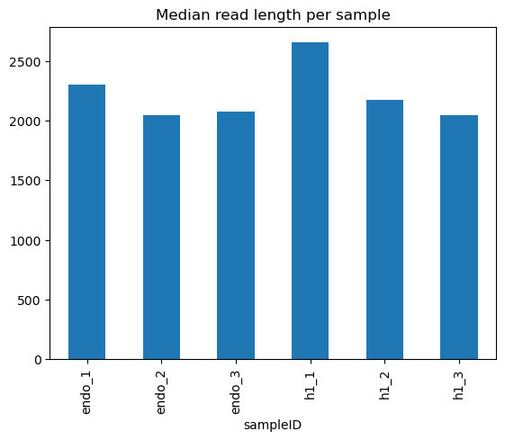

```python
col   = [c for c in length.columns if "median" in c.lower()][0]
idcol = [c for c in length.columns if c.lower() in ("sampleid","sample","id")][0]
length.plot(x=idcol, y=col, kind="bar", legend=False, title="Median read length per sample");
```

## Part 4 — Under-annotation & the multi-sample report

SQANTI-reads flags genes that are well-covered by reads but whose reference annotation may be **incomplete** (a highly-supported novel splice chain with no matching annotated transcript).

```python
ua = None
for pat in ["gene_class", "underannot"]:
    hits = glob.glob(f"out/*{pat}*.csv")
    if hits:
        ua = pd.read_csv(hits[0]); print("loaded", hits[0]); break
if ua is not None:
    display(ua.head())
    catcol = [c for c in ua.columns if "categ" in c.lower() or "class" in c.lower()]
    if catcol:
        display(ua[catcol[-1]].value_counts())
```

```
loaded out/sqantiReads_gene_classfication.csv
```

|  | associated_gene | gene_category |
| --- | --- | --- |
| 0 | ENSG00000008988.11 | annotated_with_well_covered_FSM |
| 1 | ENSG00000012232.10 | annotated_with_well_covered_FSM |
| 2 | ENSG00000014164.7 | annotated_with_well_covered_FSM |
| 3 | ENSG00000023287.13 | annotated_with_well_covered_FSM |
| 4 | ENSG00000035681.9 | annotated_with_well_covered_FSM |

```
gene_category
annotated_with_well_covered_FSM             210
annotated_with_low_coverage_FSM              18
underannotated_with_candidate_transcript      2
Name: count, dtype: int64
```

### The report (faceted by group)

SQANTI-reads renders all metrics into a PDF — structural categories, UJC counts, read length, junction CV (donors/acceptors), a cross-sample **PCA**, and the under-annotation summary — with **`endo` vs `h1`** shown side by side. We render the first pages inline.

```
main report: out/sqantiReads_plots.pdf
```

[figure not shown]

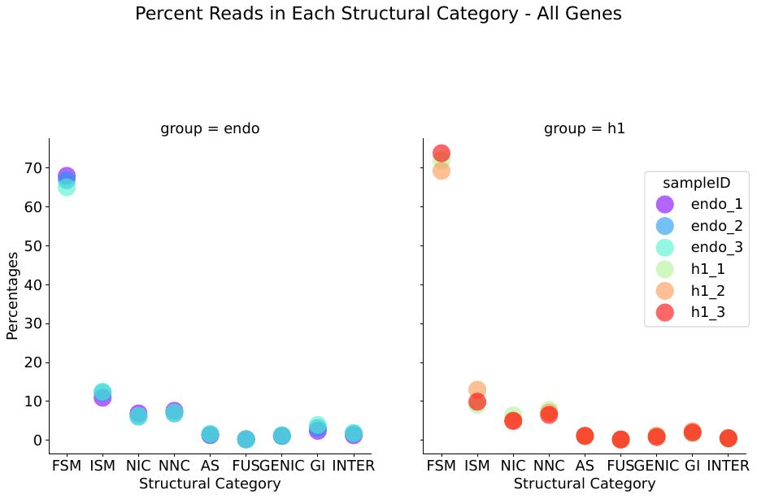

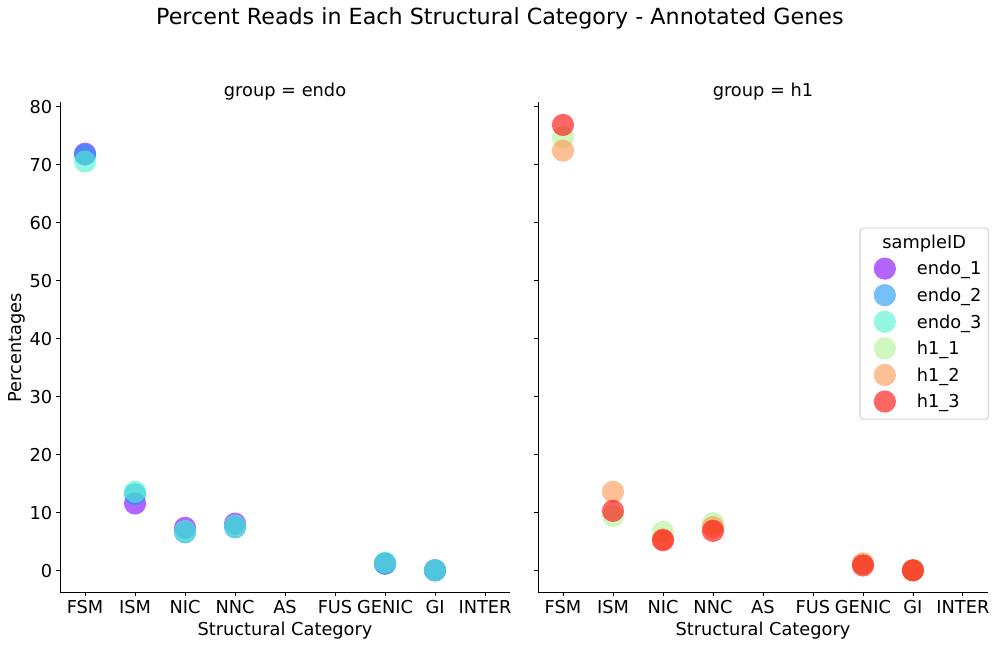

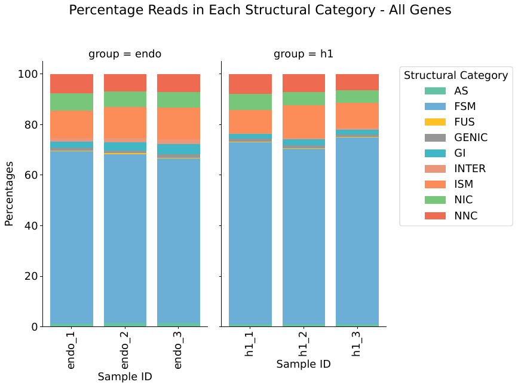

```python
from pdf2image import convert_from_path
allpdfs = glob.glob("out/*plots*.pdf")
main = [p for p in allpdfs if "annotation" not in os.path.basename(p)]
report = (main or allpdfs)[0]
print("main report:", report)
for pg in convert_from_path(report, dpi=80, first_page=1, last_page=4):
    display(pg)
```

### Discussion

- **Q3.** In the PCA / category mix, do `endo` and `h1` separate? Do replicates cluster within group? If one replicate were an outlier, what would you check first?
- **Q4.** Pick a gene flagged `underannotated_with_candidate_transcript`. What evidence supports a *missing* transcript there, and how would you confirm it?
- **Q5.** Why is the UJC (hashed splice chain) a better unit than raw read counts for comparing isoform structures across samples?

**Recap:** you mapped long reads (minimap2, splice-aware) → classified reads into structural categories (SQANTI3 QC) → aggregated 6 samples in 2 groups into UJC/length/CV/PCA metrics and an under-annotation report (SQANTI-reads), comparing **H1 vs endoderm** library quality and annotation completeness. Tomorrow you'll assemble these same reads (IsoTools) and characterize the assembly (SQANTI3).